# Machine Learning Project

August 12, 2018

### Introduction

The goal of this project is to predict the manner in which parcipants did the exercise by using data from accelerometers on the belt, forearm, arm, and dumbell of 6 participants. More information is available at: http://web.archive.org/web/20161224072740/http:/groupware.les.inf.puc-rio.br/har

### Reading and Cleaning Data

The training data set contains 19622 observations and 160 variables, while the testing data set contains 20 observations and 160 variables. The “classe” variable in the training set is the outcome to predict. There are lots of variables in the training dataset that contain too many NAs/ blank, so we need to check and remove them. The first 7 columns are not related to the result, so we will also remove them from the training dataset.

After cleaning, the training dataset has 53 columns. Then split the cleaned training set into a training data set (70%) and a validation data set (30%). Since the test dataset is independent to the training dataset, we would use the cross-validation techinique. It also offers higher accuracy.

### Machine Learning Models

*Classification Tree*

The tree plot is shown as below:

[figure not shown]

```
Confusion Matrix and Statistics


predict1    A    B    C    D    E
       A 1461  150   10   57   50
       B   88  814  138   68   71
       C   14  111  790  161   83
       D   44   56   47  643   82
       E   67    8   41   35  796

Overall Statistics

               Accuracy : 0.7653
                 95% CI : (0.7543, 0.7761)
    No Information Rate : 0.2845
    P-Value [Acc > NIR] : < 2.2e-16

                  Kappa : 0.7028
 Mcnemar's Test P-Value : < 2.2e-16

Statistics by Class:

                     Class: A Class: B Class: C Class: D Class: E
Sensitivity            0.8728   0.7147   0.7700   0.6670   0.7357
Specificity            0.9366   0.9231   0.9241   0.9535   0.9686
Pos Pred Value         0.8455   0.6904   0.6816   0.7374   0.8405
Neg Pred Value         0.9488   0.9309   0.9501   0.9360   0.9421
Prevalence             0.2845   0.1935   0.1743   0.1638   0.1839
Detection Rate         0.2483   0.1383   0.1342   0.1093   0.1353
Detection Prevalence   0.2936   0.2003   0.1969   0.1482   0.1609
Balanced Accuracy      0.9047   0.8189   0.8470   0.8102   0.8521
```

The accuracy of the classification tree model is 0.765, which is a little bit lower. We need to try another model.

*Random Forests*

```
Confusion Matrix and Statistics

   predict2
       A    B    C    D    E
  A 1671    3    0    0    0
  B    4 1135    0    0    0
  C    0    7 1017    2    0
  D    0    0   10  953    1
  E    0    0    0    3 1079

Overall Statistics

               Accuracy : 0.9949
                 95% CI : (0.9927, 0.9966)
    No Information Rate : 0.2846
    P-Value [Acc > NIR] : < 2.2e-16

                  Kappa : 0.9936
 Mcnemar's Test P-Value : NA

Statistics by Class:

                     Class: A Class: B Class: C Class: D Class: E
Sensitivity            0.9976   0.9913   0.9903   0.9948   0.9991
Specificity            0.9993   0.9992   0.9981   0.9978   0.9994
Pos Pred Value         0.9982   0.9965   0.9912   0.9886   0.9972
Neg Pred Value         0.9991   0.9979   0.9979   0.9990   0.9998
Prevalence             0.2846   0.1946   0.1745   0.1628   0.1835
Detection Rate         0.2839   0.1929   0.1728   0.1619   0.1833
Detection Prevalence   0.2845   0.1935   0.1743   0.1638   0.1839
Balanced Accuracy      0.9984   0.9952   0.9942   0.9963   0.9992
```

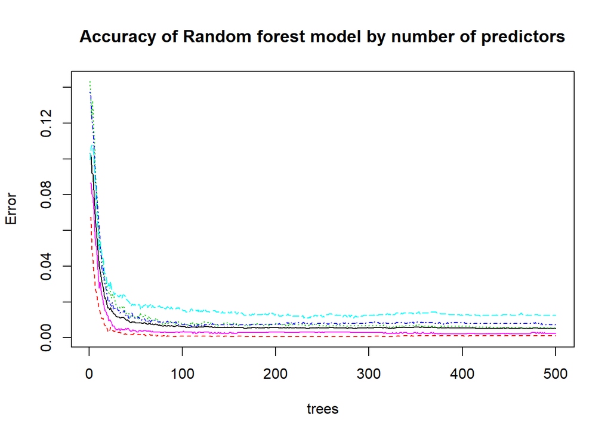

The accuracy of the random forests model is 0.995. The expected out-of-sample error is 100-99.49 = 0.51%. We will use it to predict the values of classe for the test data set.

### Predicting Results and Conclusion

The classes of the 20 test cases are shown as following:

```
 1  2  3  4  5  6  7  8  9 10 11 12 13 14 15 16 17 18 19 20
 B  A  B  A  A  E  D  B  A  A  B  C  B  A  E  E  A  B  B  B
Levels: A B C D E
```

### References

Ugulino, W.; Cardador, D.; Vega, K.; Velloso, E.; Milidiu, R.; Fuks, H. Wearable Computing: Accelerometers’ Data Classification of Body Postures and Movements. Proceedings of 21st Brazilian Symposium on Artificial Intelligence. Advances in Artificial Intelligence - SBIA 2012. In: Lecture Notes in Computer Science. , pp. 52-61. Curitiba, PR: Springer Berlin / Heidelberg, 2012. ISBN 978-3-642-34458-9. DOI: 10.1007/978-3-642-34459-6_6.

Velloso, E.; Bulling, A.; Gellersen, H.; Ugulino, W.; Fuks, H. Qualitative Activity Recognition of Weight Lifting Exercises. Proceedings of 4th International Conference in Cooperation with SIGCHI (Augmented Human ’13) . Stuttgart, Germany: ACM SIGCHI, 2013.

Ugulino, W.; Ferreira, M.; Velloso, E.; Fuks, H. Virtual Caregiver: Colaboração de Parentes no Acompanhamento de Idosos. Anais do SBSC 2012, IX Simpósio Brasileiro de Sistemas Colaborativos , pp. 43-48. São Paulo, SP: IEEE, 2012. ISBN 978-0-7695-4890-6.